# EDA - EV Charging Stations

## Data Preparation & Pre-processing

### Importing Libraries & Setting Up Data

```python
import numpy as np
import pandas as pd
from pandas import Series, DataFrame
import seaborn as sns
import matplotlib.pyplot as plt
from matplotlib import rcParams
import warnings
warnings.filterwarnings("ignore")
```

```python
address = '/workspaces/EVCFLO/Data Science - EV Stations/Data/IEA-EV-data.csv'

df = pd.read_csv(address)

df.columns = ['region', 'category', 'parameter', 'mode', 'powertrain', 'year', 'unit', 'value']
df.head(20)
```

|  | region | category | parameter | mode | powertrain | year | unit | value |
| --- | --- | --- | --- | --- | --- | --- | --- | --- |
| 0 | Australia | Historical | EV sales | Cars | BEV | 2011 | sales | 49.00000 |
| 1 | Australia | Historical | EV stock | Cars | BEV | 2011 | stock | 49.00000 |
| 2 | Australia | Historical | EV stock share | Cars | EV | 2011 | percent | 0.00046 |
| 3 | Australia | Historical | EV sales share | Cars | EV | 2011 | percent | 0.00650 |
| 4 | Australia | Historical | EV sales share | Cars | EV | 2012 | percent | 0.03000 |
| 5 | Australia | Historical | EV stock share | Cars | EV | 2012 | percent | 0.00280 |
| 6 | Australia | Historical | EV stock | Cars | BEV | 2012 | stock | 220.00000 |
| 7 | Australia | Historical | EV sales | Cars | PHEV | 2012 | sales | 80.00000 |
| 8 | Australia | Historical | EV sales | Cars | BEV | 2012 | sales | 170.00000 |
| 9 | Australia | Historical | EV stock | Cars | PHEV | 2012 | stock | 80.00000 |
| 10 | Australia | Historical | EV stock | Cars | PHEV | 2013 | stock | 180.00000 |
| 11 | Australia | Historical | EV sales | Cars | BEV | 2013 | sales | 190.00000 |
| 12 | Australia | Historical | EV sales | Cars | PHEV | 2013 | sales | 100.00000 |
| 13 | Australia | Historical | EV stock | Cars | BEV | 2013 | stock | 410.00000 |
| 14 | Australia | Historical | EV stock share | Cars | EV | 2013 | percent | 0.00540 |
| 15 | Australia | Historical | EV sales share | Cars | EV | 2013 | percent | 0.03400 |
| 16 | Australia | Historical | EV sales share | Cars | EV | 2014 | percent | 0.16000 |
| 17 | Australia | Historical | EV stock share | Cars | EV | 2014 | percent | 0.01700 |
| 18 | Australia | Historical | EV stock | Cars | BEV | 2014 | stock | 780.00000 |
| 19 | Australia | Historical | EV sales | Cars | PHEV | 2014 | sales | 950.00000 |

```python
df.describe(include='all')
```

|  | region | category | parameter | mode | powertrain | year | unit | value |
| --- | --- | --- | --- | --- | --- | --- | --- | --- |
| count | 7434 | 7434 | 7434 | 7434 | 7434 | 7434.000000 | 7434 | 7.434000e+03 |
| unique | 34 | 3 | 8 | 6 | 5 | NaN | 7 | NaN |
| top | World | Historical | EV stock | Cars | EV | NaN | percent | NaN |
| freq | 763 | 5686 | 1723 | 2684 | 2903 | NaN | 2155 | NaN |
| mean | NaN | NaN | NaN | NaN | NaN | 2018.294996 | NaN | 2.510182e+05 |
| std | NaN | NaN | NaN | NaN | NaN | 4.910528 | NaN | 3.439397e+06 |
| min | NaN | NaN | NaN | NaN | NaN | 2010.000000 | NaN | 1.700000e-07 |
| 25% | NaN | NaN | NaN | NaN | NaN | 2015.000000 | NaN | 6.900000e-01 |
| 50% | NaN | NaN | NaN | NaN | NaN | 2018.000000 | NaN | 7.600000e+01 |
| 75% | NaN | NaN | NaN | NaN | NaN | 2021.000000 | NaN | 3.700000e+03 |
| max | NaN | NaN | NaN | NaN | NaN | 2030.000000 | NaN | 1.800000e+08 |

### Treating Duplicates & Missing Values

```python
# Check data types
df.info()
```

```
<class 'pandas.core.frame.DataFrame'>
RangeIndex: 7434 entries, 0 to 7433
Data columns (total 8 columns):
 #   Column      Non-Null Count  Dtype
---  ------      --------------  -----
 0   region      7434 non-null   object
 1   category    7434 non-null   object
 2   parameter   7434 non-null   object
 3   mode        7434 non-null   object
 4   powertrain  7434 non-null   object
 5   year        7434 non-null   int64
 6   unit        7434 non-null   object
 7   value       7434 non-null   float64
dtypes: float64(1), int64(1), object(6)
memory usage: 464.8+ KB
```

```python
# Count Missing Values
print('Missing Values by Attribute:')
print(df.isnull().sum())

# Filter Out Missing Values
df_no_nan = df.dropna(axis=0)
df_no_nan2 = df.dropna(axis=1)
print('\nMISSING VALUES')
print('Shape before filtering missing values: ' + str(df.shape))
print('Shape after filtering missing values by row: ' + str(df_no_nan.shape) + 'and column: ' + str(df_no_nan2.shape))

# Counting and dropping duplicated Data Values
counted = df.duplicated().sum()
print('\nDUPLICATED VALUES')
print('Number of duplicated data values: ' + str(counted))
print('Shape before dropping duplicates: ' + str(df.shape))
df2 = df.drop_duplicates()
print('Shape after dropping duplicates: ' + str(df2.shape))
```

```
Missing Values by Attribute:
region        0
category      0
parameter     0
mode          0
powertrain    0
year          0
unit          0
value         0
dtype: int64

MISSING VALUES
Shape before filtering missing values: (7434, 8)
Shape after filtering missing values by row: (7434, 8)and column: (7434, 8)

DUPLICATED VALUES
Number of duplicated data values: 0
Shape before dropping duplicates: (7434, 8)
Shape after dropping duplicates: (7434, 8)
```

There are neither missing values or duplicated rows within the dataframe. Most of the data types are objects being parameters. The exceptions are value, and year indicating they are two important non-categorical columns. Same amount of data for each column.

### Sorting, Selecting & Grouping Data

```python
# Select EV Charging Points in the World and specifically in Australia.
ev = df[df['unit'] == 'charging points']
ev['category'].value_counts()
ev_world = ev.drop(['parameter', 'category', 'mode', 'unit'], axis='columns')
ev_world.head()
ev_aus = ev[(ev_world['region'] == 'Australia')]
ev_aus.head(10)
```

|  | region | category | parameter | mode | powertrain | year | unit | value |
| --- | --- | --- | --- | --- | --- | --- | --- | --- |
| 38 | Australia | Historical | EV charging points | EV | Publicly available fast | 2017 | charging points | 40.0 |
| 39 | Australia | Historical | EV charging points | EV | Publicly available slow | 2017 | charging points | 440.0 |
| 44 | Australia | Historical | EV charging points | EV | Publicly available fast | 2018 | charging points | 61.0 |
| 45 | Australia | Historical | EV charging points | EV | Publicly available slow | 2018 | charging points | 670.0 |
| 54 | Australia | Historical | EV charging points | EV | Publicly available fast | 2019 | charging points | 250.0 |
| 55 | Australia | Historical | EV charging points | EV | Publicly available slow | 2019 | charging points | 1700.0 |
| 60 | Australia | Historical | EV charging points | EV | Publicly available fast | 2020 | charging points | 350.0 |
| 61 | Australia | Historical | EV charging points | EV | Publicly available slow | 2020 | charging points | 2000.0 |
| 70 | Australia | Historical | EV charging points | EV | Publicly available fast | 2021 | charging points | 350.0 |
| 73 | Australia | Historical | EV charging points | EV | Publicly available slow | 2021 | charging points | 2000.0 |

## EDA - Australian EV Charging Stations

### Fast and Slow Stations

Let's visualise the change in powertrain and number of EV charging Stations in Australia between 2017 being when EV charging stations were first installed and 2021. Note there is no data or projections on an individual level for 2025 or 2030 so these data points have been left out.

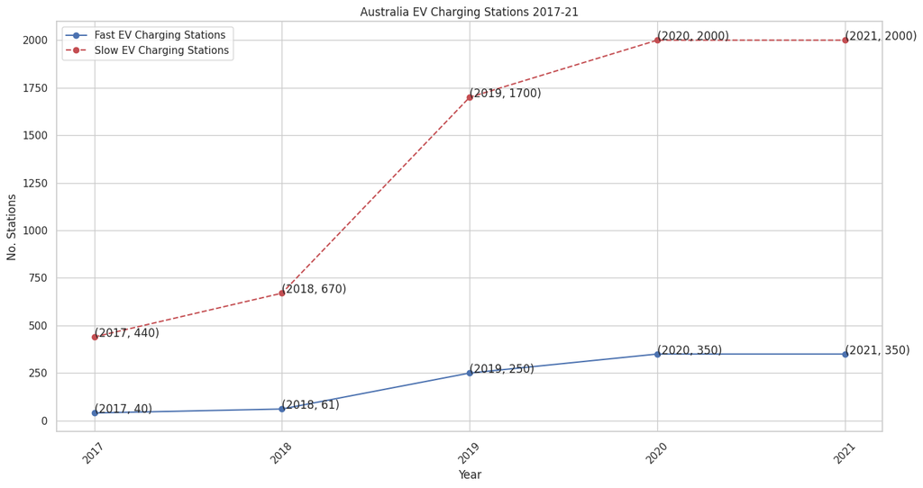

```python
# Create scatterplot showing change in Aus charging stations over time.
plt.figure(figsize=(16,8))
ev_aus_fast = ev_aus[ev_aus['powertrain'] == 'Publicly available fast']
ev_aus_slow = ev_aus[ev_aus['powertrain'] == 'Publicly available slow']

plt.plot(ev_aus_fast.year, ev_aus_fast.value, linestyle='-', marker='o', color='b',  label = 'Fast EV Charging Stations')
plt.plot(ev_aus_slow.year, ev_aus_slow.value, linestyle='--', marker='o', color='r',  label = 'Slow EV Charging Stations')

plt.xlabel("Year")
plt.ylabel("No. Stations")
plt.legend()
plt.title('Australia EV Charging Stations 2017-21')
plt.xticks(ev_aus_fast.year, ev_aus_fast.year, rotation=45)

# Show the data points for comparison of growth
for xy in zip(ev_aus_fast.year, ev_aus_fast.value):
   plt.annotate('(%.0f, %.0f)' % xy, xy=xy)

for xy in zip(ev_aus_slow.year, ev_aus_slow.value):
   plt.annotate('(%.0f, %.0f)' % xy, xy=xy)
```

```python
ev_aus_slow['value'].pct_change(fill_method='ffill')
```

```
39         NaN
45    0.522727
55    1.537313
61    0.176471
73    0.000000
Name: value, dtype: float64
```

In terms of Slow Charging stations: 2018 - 53% and 2019 - 154% saw the biggest percentage increases in slow EV Charging stations. 2020 saw only an increase of 17.6% and 2021 saw no increase, a slowdown most likely explained by the pandemic.

```python
ev_aus_fast['value'].pct_change(fill_method='ffill')
```

```
38         NaN
44    0.525000
54    3.098361
60    0.400000
70    0.000000
Name: value, dtype: float64
```

In terms of Fast EV Charging Stations: 2018 - 53% and 2019 - 310% saw the biggest percentage increases in fast EV Charging stations. Even During the pandemic in 2020 there was still a large increase in fast charging stations of 40% compared to only 17.6% for slow charging stations showing the demand for faster charges. There was no change between 2020 and 2021 which is most likely explained by the pandemic.

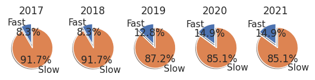

```python
# Create a barplot
explode = (0, 0.2)  # only "explode" the 2nd slice (i.e. 'Fast PowerTrains')
labels = 'Fast', 'Slow'

# Australia EV Charging Stations by each year
n_21 = ev_aus.loc[ev_aus['year'] == 2021]
n_20 = ev_aus.loc[ev_aus['year'] == 2020]
n_19 = ev_aus.loc[ev_aus['year'] == 2019]
n_18 = ev_aus.loc[ev_aus['year'] == 2018]
n_17 = ev_aus.loc[ev_aus['year'] == 2017]

# create a figure with five subplots
fig, (ax1, ax2, ax3, ax4, ax5) = plt.subplots(1,5)

# plot each pie chart in a separate subplot
ax1.pie(n_17['value'], explode=explode, labels=labels, autopct='%1.1f%%',
         shadow=True, startangle=90)
ax1.set_title('2017')
ax2.pie(n_18['value'], explode=explode, labels=labels, autopct='%1.1f%%',
         shadow=True, startangle=90)
ax2.set_title('2018')
ax3.pie(n_19['value'], explode=explode, labels=labels, autopct='%1.1f%%',
         shadow=True, startangle=90)
ax3.set_title('2019')
ax4.pie(n_20['value'], explode=explode, labels=labels, autopct='%1.1f%%',
         shadow=True, startangle=90)
ax4.set_title('2020')
ax5.pie(n_21['value'], explode=explode, labels=labels, autopct='%1.1f%%',
         shadow=True, startangle=90)
ax5.set_title('2021')

plt.show()
fig.suptitle('Powertrains of Australian EV Charging Stations')
```

The percentage of fast EV charging powertrains in Australia has increased from 8.3% in 2017 to become 14.9% in 2021. The percentage of fast EV charging stations has increased significantly since 2018 with a corresponding decrease in slow powertrains. It seems there is a trend underway in Australia towards fast powertrains over slow poerstations despite slow stations in general being cheaper.

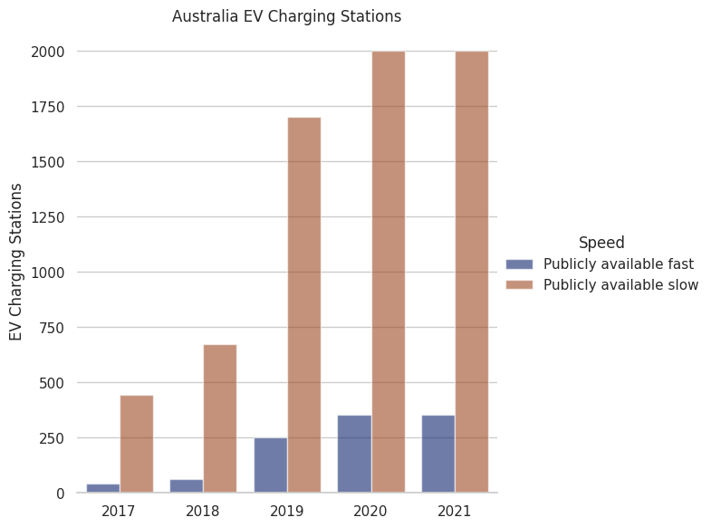

```python
# Create a grouped barplot.
import seaborn as sns
sns.set_theme(style="whitegrid")

# Draw a nested barplot for year and value
g = sns.catplot(
    data=ev_aus, kind="bar",
    x="year", y="value", hue="powertrain",
    errorbar="sd", palette="dark", alpha=.6, height=6,
)
g.despine(left=True)
g.set_axis_labels("", "EV Charging Stations")
g.legend.set_title("Speed")
g.set(title = 'Australia EV Charging Stations')
```

### Total Australian EV Charging Stations

```python
# Creating a new simplified DF for EV charging stations by powertrain in Australia
ev_aus = ev[(ev['parameter'] == 'EV charging points') & (ev['region'] == 'Australia')]
ev_aus = ev_aus.drop(['region', 'category', 'parameter',
             'mode', 'unit'], axis = 1)
ev_aus = ev_aus.replace( {'Publicly available fast':'Fast', 'Publicly available slow':'Slow'})
ev_aus
```

|  | powertrain | year | value |
| --- | --- | --- | --- |
| 38 | Fast | 2017 | 40.0 |
| 39 | Slow | 2017 | 440.0 |
| 44 | Fast | 2018 | 61.0 |
| 45 | Slow | 2018 | 670.0 |
| 54 | Fast | 2019 | 250.0 |
| 55 | Slow | 2019 | 1700.0 |
| 60 | Fast | 2020 | 350.0 |
| 61 | Slow | 2020 | 2000.0 |
| 70 | Fast | 2021 | 350.0 |
| 73 | Slow | 2021 | 2000.0 |

```python
# Total EV Charging Stations in Australia
ev_aus_total = ev_aus.groupby('year').aggregate('sum')
ev_aus_total = pd.DataFrame(ev_aus_total)
ev_aus_total.columns = ['powertrain', 'value']
ev_aus_total
```

| year | powertrain | value |
| --- | --- | --- |
| 2017 | FastSlow | 480.0 |
| 2018 | FastSlow | 731.0 |
| 2019 | FastSlow | 1950.0 |
| 2020 | FastSlow | 2350.0 |
| 2021 | FastSlow | 2350.0 |

```python
# See percentage change in total Aus. EV Charging Stations
ev_aus_total['value'].pct_change(fill_method='ffill')
```

```
year
2017         NaN
2018    0.522917
2019    1.667579
2020    0.205128
2021    0.000000
Name: value, dtype: float64
```

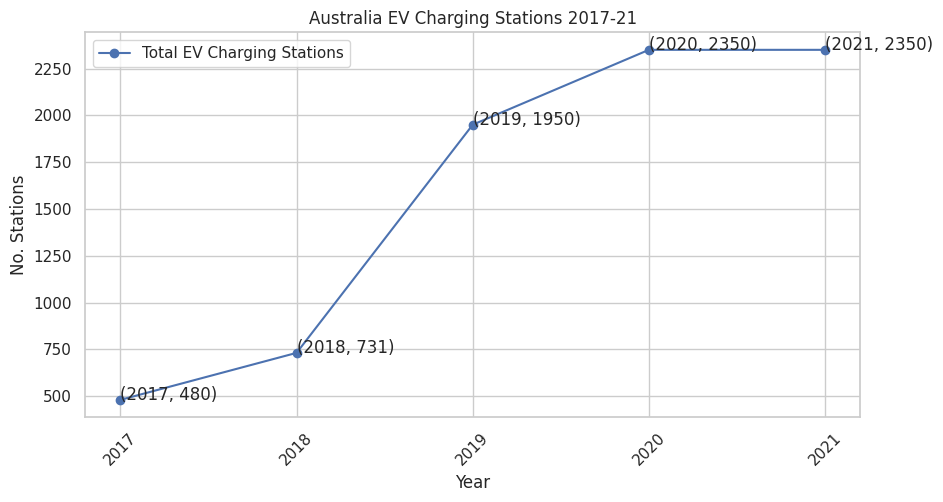

```python
# Create a Plot
plt.figure(figsize=(10,5))
plt.plot(ev_aus_total.index, ev_aus_total.value, linestyle='-', marker='o', color='b',  label = 'Total EV Charging Stations')

plt.xlabel("Year")
plt.ylabel("No. Stations")
plt.legend()
plt.title('Australia EV Charging Stations 2017-21')
plt.xticks(ev_aus_fast.year, ev_aus_fast.year, rotation=45)

# Show the data points for comparison of growth
for xy in zip(ev_aus_total.index, ev_aus_total.value):
   plt.annotate('(%.0f, %.0f)' % xy, xy=xy)
```

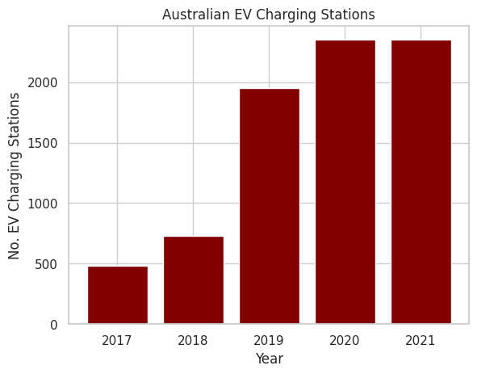

```python
# Create Basic barplot and set labels
plt.bar(ev_aus_total.index, ev_aus_total.value, color = 'maroon', width=0.8, align='center')
plt.xlabel("Year")
plt.ylabel("No. EV Charging Stations")
plt.title("Australian EV Charging Stations")
plt.show()
```

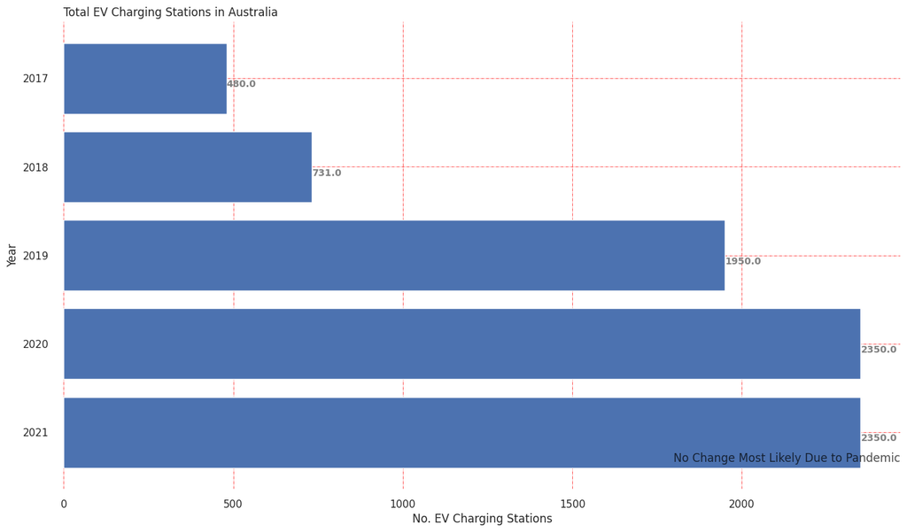

```python
# Figure Size
fig, ax = plt.subplots(figsize =(16, 9))
# Horizontal Bar Plot
ax.barh(ev_aus_total.index, ev_aus_total.value)

# Remove axes splines
for s in ['top', 'bottom', 'left', 'right']:
    ax.spines[s].set_visible(False)

# Remove x, y Ticks
ax.xaxis.set_ticks_position('none')
ax.yaxis.set_ticks_position('none')

# Add padding between axes and labels
ax.xaxis.set_tick_params(pad = 5)
ax.yaxis.set_tick_params(pad = 10)

# Add x, y gridlines
ax.grid(color ='red',
        linestyle ='-.', linewidth = 0.5,
        alpha = 0.9)

# Show top values
ax.invert_yaxis()

# Axis labels
plt.xlabel("No. EV Charging Stations")
plt.ylabel("Year")

# Add annotation to bars
for i in ax.patches:
    plt.text(i.get_width()+0.2, i.get_y()+0.5,
             str(round((i.get_width()), 2)),
             fontsize = 10, fontweight ='bold',
             color ='grey')

# Add Plot Title
ax.set_title('Total EV Charging Stations in Australia',
             loc ='left', )

# Add Text watermark
fig.text(0.9, 0.15, 'No Change Most Likely Due to Pandemic', fontsize = 12,
         color ='black', ha ='right', va ='bottom',
         alpha = 0.7)

# Show Plot
plt.show()
```

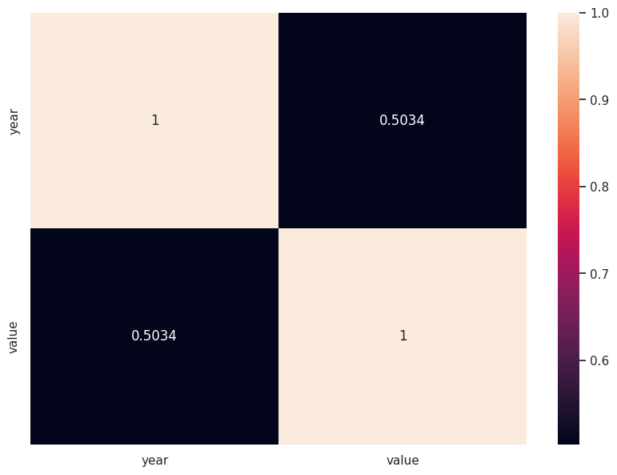

```python
# sns.barplot(data=ev_aus_total, x="year", y="value", errorbar="sd")
# ax = sns.barplot(data=ev_aus_total, x='powertrain', y='value', hue='card_name')
ev_aus_total2 = ev_aus.drop('powertrain', axis=1)
plt.figure(figsize=(10,7))
sns.heatmap(ev_aus_total2.corr(), fmt='.4g', annot=True)
```

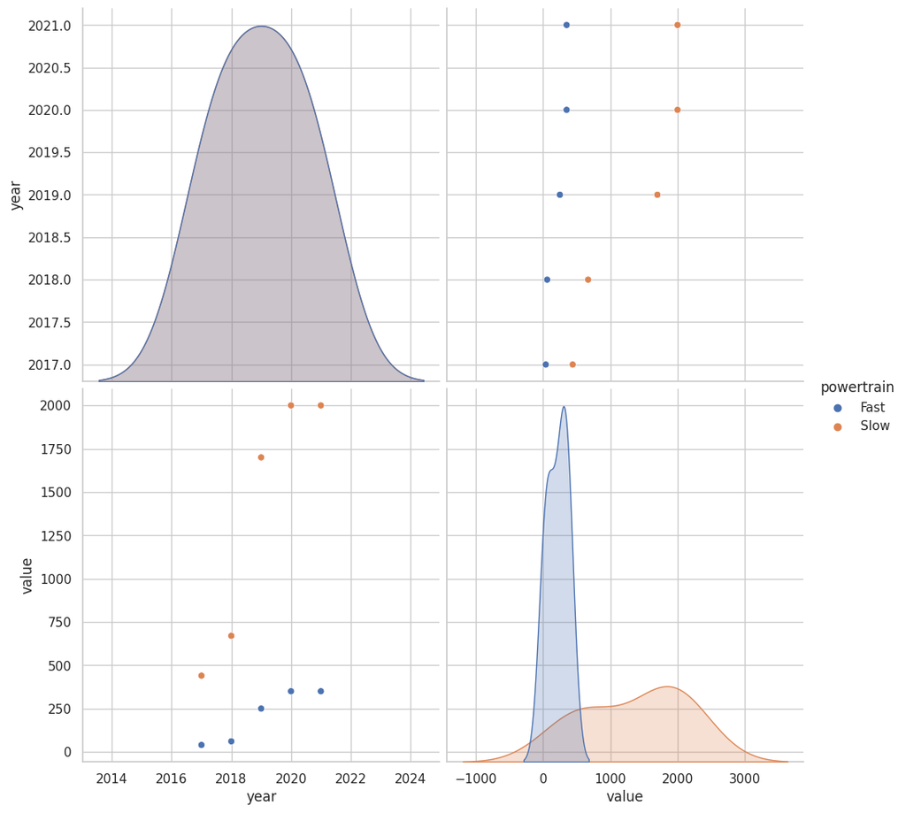

```python
##create pairplots using seaborn
%matplotlib inline
sns.pairplot(ev_aus, hue='powertrain', height = 5) # correlation between different variables.
```

### Conclusion Australian EV Charging Station Data

Another interesting insight is that there was no change in this data set between the amount of EV Charging stations in 2020 and 2021. This is most likely due to the Pandemic with lockdowns, lost business and significant restrictions on global trade stopping money altogether being spent on EV Charging stations. However, further research to see if this is due to other factors would also be interesting. Analysing the difference between 2021 to 2022 and 2022 to 2023 will be particularly interesting to see if there has been a significant increase in growth as the pandemic has subsided.

## EDA on World Data

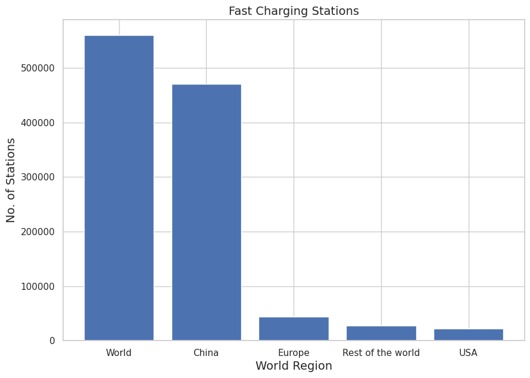

```python
# Fast charging stations in 2021
f = ev.loc[(ev['powertrain'] == 'Publicly available fast') & (ev['year'] == 2021)]
f2 = f.drop_duplicates(subset=['region'])
l = f2.nlargest(5, 'value')

# Figure Size
fig = plt.figure(figsize =(10, 7))

# Vertical Bar Plot
plt.bar(l['region'], l['value'])

# Show Plot
plt.title('Fast Charging Stations', fontsize=14)
plt.xlabel('World Region', fontsize=14)
plt.ylabel('No. of Stations', fontsize=14)
plt.grid(True)
plt.show()
```

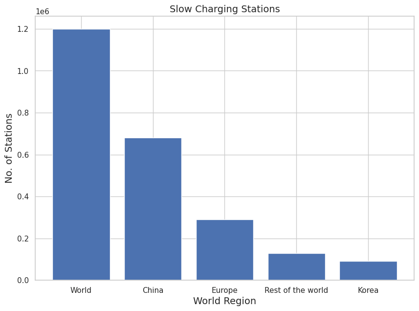

```python
# Slow charging stations in 2021
f = ev.loc[(ev['powertrain'] == 'Publicly available slow') & (ev['year'] == 2021)]
f2 = f.drop_duplicates(subset=['region'])
l = f2.nlargest(5, 'value')

# Figure Size
fig = plt.figure(figsize =(10, 7))

# Vertical Bar Plot
plt.bar(l['region'], l['value'])

# Show Plot
plt.title('Slow Charging Stations', fontsize=14)
plt.xlabel('World Region', fontsize=14)
plt.ylabel('No. of Stations', fontsize=14)
plt.grid(True)
plt.show()
```

```python
# Select all the EV Charging stations for the entire world
ev_world1 = ev_world[ev_world['region'] == 'World'].drop_duplicates()

# Check the unique values
ev_world1.select_dtypes(include='object').nunique()
```

```
region        1
powertrain    2
dtype: int64
```

1 region being the world and 2 different powertrains being fast and slow charging stations. This makes sense.

```python
ev_world1
```

|  | region | powertrain | year | value |
| --- | --- | --- | --- | --- |
| 6697 | World | Publicly available fast | 2010 | 310.0 |
| 6698 | World | Publicly available slow | 2010 | 3700.0 |
| 6703 | World | Publicly available fast | 2011 | 830.0 |
| 6704 | World | Publicly available slow | 2011 | 10000.0 |
| 6736 | World | Publicly available fast | 2012 | 1700.0 |
| 6737 | World | Publicly available slow | 2012 | 30000.0 |
| 6766 | World | Publicly available fast | 2013 | 3800.0 |
| 6767 | World | Publicly available slow | 2013 | 44000.0 |
| 6795 | World | Publicly available fast | 2014 | 15000.0 |
| 6796 | World | Publicly available slow | 2014 | 91000.0 |
| 6835 | World | Publicly available fast | 2015 | 27000.0 |
| 6836 | World | Publicly available slow | 2015 | 160000.0 |
| 6867 | World | Publicly available fast | 2016 | 75000.0 |
| 6868 | World | Publicly available slow | 2016 | 260000.0 |
| 6919 | World | Publicly available fast | 2017 | 110000.0 |
| 6920 | World | Publicly available slow | 2017 | 330000.0 |
| 6950 | World | Publicly available fast | 2018 | 140000.0 |
| 6951 | World | Publicly available slow | 2018 | 400000.0 |
| 7000 | World | Publicly available fast | 2019 | 270000.0 |
| 7001 | World | Publicly available slow | 2019 | 630000.0 |
| 7034 | World | Publicly available fast | 2020 | 390000.0 |
| 7035 | World | Publicly available slow | 2020 | 910000.0 |
| 7148 | World | Publicly available fast | 2021 | 560000.0 |
| 7149 | World | Publicly available slow | 2021 | 1200000.0 |
| 7262 | World | Publicly available fast | 2025 | 2100000.0 |
| 7263 | World | Publicly available slow | 2025 | 4800000.0 |
| 7297 | World | Publicly available fast | 2025 | 1900000.0 |
| 7298 | World | Publicly available slow | 2025 | 4200000.0 |
| 7364 | World | Publicly available fast | 2030 | 5400000.0 |
| 7365 | World | Publicly available slow | 2030 | 9900000.0 |
| 7399 | World | Publicly available fast | 2030 | 4700000.0 |
| 7400 | World | Publicly available slow | 2030 | 8200000.0 |

```python
# Let's drop the high estimates in order to be conservative in predicting charging stations for 2025 and 2030
ev_world1.drop([7262,7263], axis=0)
ev_world1.drop([7399,7400], axis=0)
# ev_world1.drop(7399, axis=0)
```

|  | region | powertrain | year | value |
| --- | --- | --- | --- | --- |
| 6697 | World | Publicly available fast | 2010 | 310.0 |
| 6698 | World | Publicly available slow | 2010 | 3700.0 |
| 6703 | World | Publicly available fast | 2011 | 830.0 |
| 6704 | World | Publicly available slow | 2011 | 10000.0 |
| 6736 | World | Publicly available fast | 2012 | 1700.0 |
| 6737 | World | Publicly available slow | 2012 | 30000.0 |
| 6766 | World | Publicly available fast | 2013 | 3800.0 |
| 6767 | World | Publicly available slow | 2013 | 44000.0 |
| 6795 | World | Publicly available fast | 2014 | 15000.0 |
| 6796 | World | Publicly available slow | 2014 | 91000.0 |
| 6835 | World | Publicly available fast | 2015 | 27000.0 |
| 6836 | World | Publicly available slow | 2015 | 160000.0 |
| 6867 | World | Publicly available fast | 2016 | 75000.0 |
| 6868 | World | Publicly available slow | 2016 | 260000.0 |
| 6919 | World | Publicly available fast | 2017 | 110000.0 |
| 6920 | World | Publicly available slow | 2017 | 330000.0 |
| 6950 | World | Publicly available fast | 2018 | 140000.0 |
| 6951 | World | Publicly available slow | 2018 | 400000.0 |
| 7000 | World | Publicly available fast | 2019 | 270000.0 |
| 7001 | World | Publicly available slow | 2019 | 630000.0 |
| 7034 | World | Publicly available fast | 2020 | 390000.0 |
| 7035 | World | Publicly available slow | 2020 | 910000.0 |
| 7148 | World | Publicly available fast | 2021 | 560000.0 |
| 7149 | World | Publicly available slow | 2021 | 1200000.0 |
| 7262 | World | Publicly available fast | 2025 | 2100000.0 |
| 7263 | World | Publicly available slow | 2025 | 4800000.0 |
| 7297 | World | Publicly available fast | 2025 | 1900000.0 |
| 7298 | World | Publicly available slow | 2025 | 4200000.0 |
| 7364 | World | Publicly available fast | 2030 | 5400000.0 |
| 7365 | World | Publicly available slow | 2030 | 9900000.0 |